# Clothing Classification

Guidelines for completing the project

```
Find a dataset online (either download and existing dataset or create one from web scraping, Google images etc.)
Understand and describe the modeling objective clearly
    What type of data is it? (images, text, audio etc.)
    What type of problem is it? (regression, classification, generative modeling, etc.)
Exploratory data analysis - explore the data by plotting graphs and answer any questions you may have
Modeling - try 4-5 approaches
    Define a model (network architecture)
    Pick some hyperparameters
    Train the model
    Make predictions on samples
    Evaluate on test dataset
    Save the model weights
    Record the metrics
Conclusions - summarize your learning & identify opportunities for future work
Write a blog post to describe your experiments and summarize your work - this is the final submission. Use Github pages or Medium. Submit here: https://forms.gle/rHxCqBhDGbh2Zn8L8
```

## New Section

```python
!pip install jovian --upgrade --quiet
```

```python
my_name = 'Maxinstellar' # Maksim Tingaev
```

```python
# LINK TO MY PROJECT ON GOOGLE DRIVE - DATASET + IPYNB + MODELS + PLOTS + DATAFRAME (LOSSES+ACCURACIES)
# https://drive.google.com/drive/folders/1UDRAdp4uMU-ky-mZkqDDBNSLFfAyFNyz?usp=sharing
```

```python
from google.colab import drive
drive.mount('/content/drive')
```

```python
#pip install torch==1.4.0 torchvision==0.5.0 -f https://download.pytorch.org/whl/torch_stable.html
```

```python
import torch
import torch.nn as nn
import torch.optim as optim
from torch.optim import lr_scheduler
import torchvision
from torchvision import datasets, models, transforms
import os, copy, time
from multiprocessing import Process, freeze_support
import pandas as pd
import matplotlib.pyplot as plt
import seaborn as sns
import numpy as np
from pylab import rcParams
from tqdm import tqdm
```

```python
%matplotlib inline
%config InlineBackend.figure_format='retina'
sns.set(style='whitegrid', palette='muted', font_scale=1.2)
HAPPY_COLORS_PALETTE = ["#01BEFE", "#FFDD00", "#FF7D00", "#FF006D", "#ADFF02", "#8F00FF"]
sns.set_palette(sns.color_palette(HAPPY_COLORS_PALETTE))
rcParams['figure.figsize'] = 12, 8
RANDOM_SEED = 42
np.random.seed(RANDOM_SEED)
torch.manual_seed(RANDOM_SEED)
```

```
<torch._C.Generator at 0x7f19d9c29310>
```

```python
!nvcc --version
```

```
nvcc: NVIDIA (R) Cuda compiler driver
Copyright (c) 2005-2019 NVIDIA Corporation
Built on Sun_Jul_28_19:07:16_PDT_2019
Cuda compilation tools, release 10.1, V10.1.243
```

I took a dress dataset from the Internet. The type of my data are images. There are 6 classes of clothing. We can learn our pretrained ResNeet18 model to learn to classify such images.

```python
import os           # !nvcc --version
import random
import shutil
from tqdm.notebook import tqdm

path = "/content/drive/My Drive/Colab Notebooks/Clothing classification"
data_path = os.path.join(path, "dataset")
data_ttv_path = os.path.join(path, "test_train_split")


class Next_name:
    # Let's make our own class-Iterator to shuffle images
    # And to name them automatically
    def __init__(self, list_of_items, start=0):
        self.num = start
        random.shuffle(list_of_items)
        self.list_of_items = list_of_items

    def __iter__(self):
        return self

    def __next__(self):
        item = self.list_of_items[self.num]
        self.num += 1
        return item

# Create Data folder
names = {}
if not os.path.exists(data_ttv_path):
    os.mkdir(data_ttv_path)

# Save paths to [train, test, val]
train_path = os.path.join(data_ttv_path, "train")
test_path = os.path.join(data_ttv_path, "test")
val_path = os.path.join(data_ttv_path, "val")

# Make folders if they do not exists [train, test, val]
list_of_train_test_val = [train_path, test_path, val_path]
for path in list_of_train_test_val:
    if not os.path.exists(path):
        os.mkdir(path)
    for folder in os.listdir(data_path):
        cur_path = os.path.join(path, folder)
        print(f'cur_path = {cur_path}')
        if not os.path.exists(cur_path):
            os.mkdir(cur_path)


def copy_file(i, quantity, shuffled_images, folder_name):
    # Copy to train/test/val
    folder_from = os.path.join(data_path, folder_name)
    folder_to = ''
    if i <= round(0.8 * quantity):
        folder_to = os.path.join(train_path, folder_name)
    elif i <= round(0.9 * quantity):
        folder_to = os.path.join(val_path, folder_name)
    else:
        folder_to = os.path.join(test_path, folder_name)
    try:
        image_name = next(shuffled_images)
        image_from_path = os.path.join(folder_from, image_name)
        if (os.path.exists(image_from_path)) and (os.path.getsize(image_from_path) > 0):
            #print(f'os.path.join(folder_to, image_name) = {os.path.join(folder_to, image_name)}')
            shutil.copy(image_from_path, os.path.join(folder_to, image_name))
        else:
            print(f'Error! File {image_from_path} do not exists!')
            print(f'File size = {os.path.getsize(image_from_path)}')
    except Exception as inst:
        print(inst)


def make_test_train_again():
    # Copy all files to train/test/val
    for i in tqdm(range(len(os.listdir(data_path)))):
        folder_name = os.listdir(data_path)[i]
        folder_from = os.path.join(data_path, folder_name)
        files_in_folder = os.listdir(folder_from)
        quantity =len(os.listdir(folder_from))
        shuffled_images = Next_name(os.listdir(folder_from))
        for i in tqdm(range(len(files_in_folder))):
            copy_file(i, quantity, shuffled_images, folder_name)

# Copy to train/test/val
make_test_train_again()
```

```python
# Project main path
path = "/content/drive/My Drive/Colab Notebooks/Clothing classification"

# Where to save our model
path_folder = os.path.join(path,'models')
# Model name to save as
model_path = os.path.join(path_folder, 'clothing_classification.pt')
#
data_dir = os.path.join(path, "test_train_split")
# Test folder path
test_path = os.path.join(data_dir, "test")
```

```python
# Check if CUDA is available
print(f'torch.cuda.is_available() = {torch.cuda.is_available()}')

# Let's see CUDA version installed
print(torch.__version__)

# Try to use CUDA if it is available, otherwise use CPU
device = torch.device("cuda:0" if torch.cuda.is_available() else "cpu")
print(f'device = {device}, count = {torch.cuda.device_count()}, device_name = {torch.cuda.get_device_name(0)}')
```

```
torch.cuda.is_available() = True
1.5.1+cu101
device = cuda:0, count = 1, device_name = Tesla T4
```

```python
# Data augmentation and normalization for training Just normalization for validation
data_transforms = {
    'train': transforms.Compose([
        transforms.RandomRotation(15),
        transforms.Resize(size=(224, 224), interpolation=3),
        transforms.RandomGrayscale(p=0.2),
        transforms.RandomHorizontalFlip(),
        transforms.ToTensor(),
        transforms.Normalize([0.485, 0.456, 0.406], [0.229, 0.224, 0.225])
    ]),
    'val': transforms.Compose([
        transforms.Resize(size=(224, 224), interpolation=3),
        transforms.ToTensor(),
        transforms.Normalize([0.485, 0.456, 0.406], [0.229, 0.224, 0.225])
    ])
}
```

```python
# Make shure image_datasets have rigth classes names
class_names = image_datasets['train'].classes
inputs, classes = next(iter(dataloaders['train']))  # Get a batch of training data
out = torchvision.utils.make_grid(inputs)
```

```python
train_dir = os.path.join(data_dir, "train")
classes_counts = list([(folder, len(os.listdir(os.path.join(train_dir, folder)))) for folder in os.listdir(train_dir)])
counts = list([class_count[1] for class_count in classes_counts])
all_data_count = sum(counts)
print(f'Count of all photos = {all_data_count}')
print(f'Photos counts per class = {counts}')
print(f'classnames = {class_names}')
```

```
Count of all photos = 1740
Photos counts per class = [286, 305, 310, 276, 296, 267]
classnames = ['black_jeans', 'blue_dress', 'blue_jeans', 'blue_shirt', 'red_dress', 'red_shirt']
```

```python
# Let's make dataloaders for training and validation dataset
image_datasets = {x: datasets.ImageFolder(os.path.join(data_dir, x), data_transforms[x]) for x in ['train', 'val']}
dataloaders = {x: torch.utils.data.DataLoader(image_datasets[x], batch_size=128, shuffle=True, num_workers=4) for x in ['train', 'val']}

# So, make dataset_sizes to know how many photos we have on train and val
dataset_sizes = {x: len(image_datasets[x]) for x in ['train', 'val']}

# Max_of_counts_dataset - this variable is needed to make wheights for CrossEntropy metricks
max_of_counts_dataset = max(counts)

# Div_func divide max_of_counts_dataset to class_count
# Max (Number of occurrences in most common class ) / (Number of occurrences in rare classes)
div_func = lambda class_count: max_of_counts_dataset / class_count

# I also tried this one variant for div_func - this one shoed worse results
# div_func = lambda class_count: 1 / class_count # classes_weights = list(map(div_func, counts))
classes_weights = list(map(div_func, counts))
```

```python
for i in range(len(counts)):
    print(f'{class_names[i]} - {counts[i]}')
```

```
black_jeans - 286
blue_dress - 305
blue_jeans - 310
blue_shirt - 276
red_dress - 296
red_shirt - 267
```

Let's see what classes we have and how many photos

```
['black_jeans', 'blue_dress', 'blue_jeans', 'blue_shirt', 'red_dress', 'red_shirt']
```

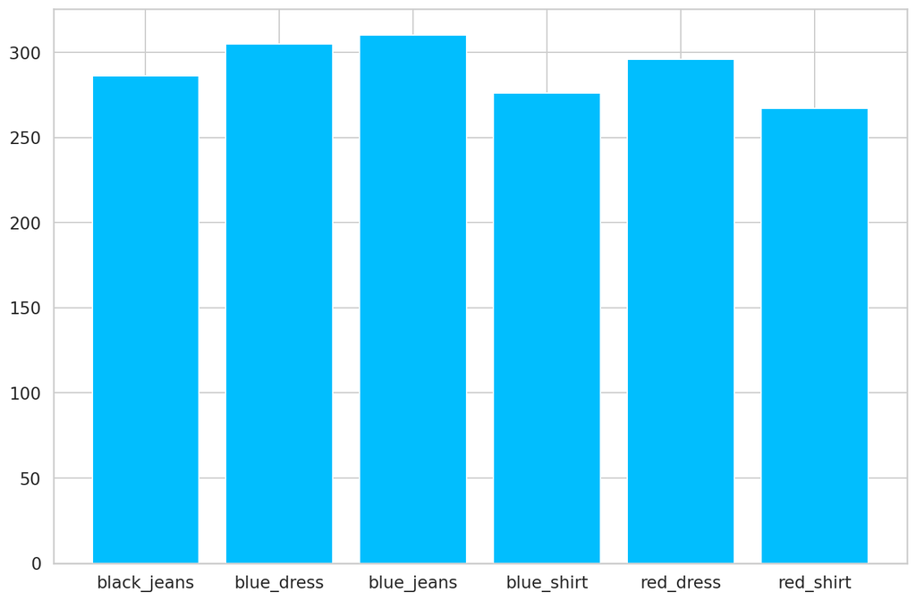

```python
print(class_names)

plt.bar(class_names, height=counts);
```

The classes are quite equal in photos counts.

Let's see what wheight we've got:

```
['black_jeans', 'blue_dress', 'blue_jeans', 'blue_shirt', 'red_dress', 'red_shirt']
```

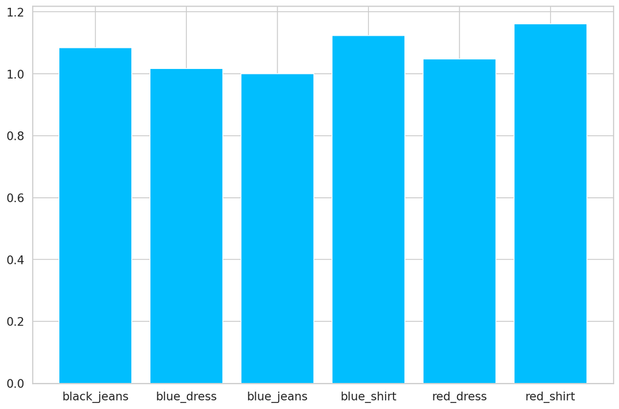

```python
print(class_names)

plt.bar(class_names, height=classes_weights);
```

We can see that wheight are more if class count is less

Function to visualize the image

```python
def imshow(inp, title=None):
    """Imshow for Tensor."""
    global mean, std
    inp = inp.numpy().transpose((1, 2, 0))
    mean = np.array([0.485, 0.456, 0.406])
    std = np.array([0.229, 0.224, 0.225])
    inp = std * inp + mean
    inp = np.clip(inp, 0, 1)
    plt.imshow(inp)
    if title is not None:
        plt.title(title)
    plt.pause(0.001)  # pause a bit so that plots are updated
```

Function to visualize the model

```python
def visualize_model(model, num_images=7):
    was_training = model.training
    model.eval()
    images_so_far = 0
    fig = plt.figure()
    predictions = []
    with torch.no_grad():
        for i, (inputs, labels) in enumerate(dataloaders['val']):
            inputs = inputs.to(device)
            labels = labels.to(device)
            outputs = model(inputs)
            _, preds = torch.max(outputs, 1)
            predictions.append(preds)
            for j in range(inputs.size()[0]):
                images_so_far += 1
                ax = plt.subplot(num_images//2, 2, images_so_far)
                ax.axis('off')
                ax.set_title('predicted: {}'.format(class_names[preds[j]]))
                imshow(inputs.cpu().data[j])
                if images_so_far == num_images:
                    model.train(mode=was_training)
                    return predictions
        model.train(mode=was_training)
```

Let's build our model

```python
def train_model(model, criterion, optimizer, scheduler, num_epochs=25):
    since = time.time()
    list_of_losses = {'train': [], 'val': []}
    list_of_accuracies = {'train': [], 'val': []}
    best_model_wts = copy.deepcopy(model.state_dict())
    best_acc = 0.0
    for epoch in range(num_epochs):
        print('Epoch {}/{}'.format(epoch, num_epochs - 1))
        print('-' * 10)
        # Each epoch has a training and validation phase
        for phase in ['train', 'val']:
            if phase == 'train':
                model.train()  # Set model to training mode
            else:
                model.eval()   # Set model to evaluate mode
            running_loss = 0.0
            running_corrects = 0
            # Iterate over data.
            for inputs, labels in dataloaders[phase]:
                inputs = inputs.to(device)
                labels = labels.to(device)
                # zero the parameter gradients
                optimizer.zero_grad()
                # forward
                # track history if only in train
                with torch.set_grad_enabled(phase == 'train'):
                    outputs = model(inputs)
                    _, preds = torch.max(outputs, 1)
                    loss = criterion(outputs, labels)
                    # backward + optimize only if in training phase
                    if phase == 'train':
                        loss.backward()
                        optimizer.step()
                # statistics
                running_loss += loss.item() * inputs.size(0)
                running_corrects += torch.sum(preds == labels.data)
            if phase == 'train':
                scheduler.step()
            epoch_loss = running_loss / dataset_sizes[phase]
            epoch_acc = running_corrects.double() / dataset_sizes[phase]
            list_of_losses[phase].append(epoch_loss)
            list_of_accuracies[phase].append(float(epoch_acc))
            print('{} Loss: {:.4f} Acc: {:.4f}'.format(phase, epoch_loss, epoch_acc))
            # deep copy the model
            if phase == 'val' and epoch_acc > best_acc:
                best_acc = epoch_acc
                best_model_wts = copy.deepcopy(model.state_dict())
        print()
    time_elapsed = time.time() - since
    print('Training complete in {:.0f}m {:.0f}s'.format(time_elapsed // 60, time_elapsed % 60))
    print('Best val Acc: {:4f}'.format(best_acc))
    # load best model weights
    model.load_state_dict(best_model_wts)
    return model, list_of_losses, list_of_accuracies
```

I took pretrained ResNet-18 model and unfreeze the last 2 layers - layer 3 and layer 4

```python
model_ft = models.resnet18(pretrained=True, progress=True)
num_ftrs = model_ft.fc.in_features
# num_ftrs = 512
print(f'num_ftrs = {num_ftrs}')
count = 0
for name, child in model_ft.named_children():
    count += 1
    if name in ['layer3', 'layer4']: # , 'avgpool', 'fc'
        print(f'Layer_{count} with name {name} is UNfrozen!')
        for param in child.parameters():
            param.requires_grad = True
    else:
        print(f'Layer_{count} with name {name} is frozen')
        for param in child.parameters():
            param.requires_grad = False
```

```
Downloading: "https://download.pytorch.org/models/resnet18-5c106cde.pth" to /root/.cache/torch/checkpoints/resnet18-5c106cde.pth
```

```
num_ftrs = 512
Layer_1 with name conv1 is frozen
Layer_2 with name bn1 is frozen
Layer_3 with name relu is frozen
Layer_4 with name maxpool is frozen
Layer_5 with name layer1 is frozen
Layer_6 with name layer2 is frozen
Layer_7 with name layer3 is UNfrozen!
Layer_8 with name layer4 is UNfrozen!
Layer_9 with name avgpool is frozen
Layer_10 with name fc is frozen
```

Add fc layer to the model for making predictions for our 6 classes

```python
# class_names = 6 - the number of classes
# tuning the layer with 512 num_ftrs
model_ft.fc = nn.Linear(num_ftrs, len(class_names))

# make our model to be on device (CUDA)
model_ft = model_ft.to(device)

# If we want to use classes_weights, then we should
# also put it into device
class_weights = torch.FloatTensor(classes_weights).cuda()

# As a criterion while training we use CrossEntropyLoss
# with weight parameter which takes class_weights
criterion = nn.CrossEntropyLoss(weight=class_weights)

# As an optimizer I took SGD after some experiments whith different optimizers and learning rates
optimizer_ft = optim.SGD(model_ft.parameters(), lr=0.001, momentum=0.9, nesterov=False)

# Make the optimizer iterate over all tensors and stored grad to update their values
exp_lr_scheduler = lr_scheduler.StepLR(optimizer_ft, step_size=7, gamma=0.2, last_epoch=-1)

# I stopped on 25 epochs
num_epochs = 25
```

Visualize our model

```python
model_ft.eval()
```

```
ResNet(
  (conv1): Conv2d(3, 64, kernel_size=(7, 7), stride=(2, 2), padding=(3, 3), bias=False)
  (bn1): BatchNorm2d(64, eps=1e-05, momentum=0.1, affine=True, track_running_stats=True)
  (relu): ReLU(inplace=True)
  (maxpool): MaxPool2d(kernel_size=3, stride=2, padding=1, dilation=1, ceil_mode=False)
  (layer1): Sequential(
    (0): BasicBlock(
      (conv1): Conv2d(64, 64, kernel_size=(3, 3), stride=(1, 1), padding=(1, 1), bias=False)
      (bn1): BatchNorm2d(64, eps=1e-05, momentum=0.1, affine=True, track_running_stats=True)
      (relu): ReLU(inplace=True)
      (conv2): Conv2d(64, 64, kernel_size=(3, 3), stride=(1, 1), padding=(1, 1), bias=False)
      (bn2): BatchNorm2d(64, eps=1e-05, momentum=0.1, affine=True, track_running_stats=True)
    )
    (1): BasicBlock(
      (conv1): Conv2d(64, 64, kernel_size=(3, 3), stride=(1, 1), padding=(1, 1), bias=False)
      (bn1): BatchNorm2d(64, eps=1e-05, momentum=0.1, affine=True, track_running_stats=True)
      (relu): ReLU(inplace=True)
      (conv2): Conv2d(64, 64, kernel_size=(3, 3), stride=(1, 1), padding=(1, 1), bias=False)
      (bn2): BatchNorm2d(64, eps=1e-05, momentum=0.1, affine=True, track_running_stats=True)
    )
  )
  (layer2): Sequential(
    (0): BasicBlock(
      (conv1): Conv2d(64, 128, kernel_size=(3, 3), stride=(2, 2), padding=(1, 1), bias=False)
      (bn1): BatchNorm2d(128, eps=1e-05, momentum=0.1, affine=True, track_running_stats=True)
      (relu): ReLU(inplace=True)
      (conv2): Conv2d(128, 128, kernel_size=(3, 3), stride=(1, 1), padding=(1, 1), bias=False)
      (bn2): BatchNorm2d(128, eps=1e-05, momentum=0.1, affine=True, track_running_stats=True)
      (downsample): Sequential(
        (0): Conv2d(64, 128, kernel_size=(1, 1), stride=(2, 2), bias=False)
        (1): BatchNorm2d(128, eps=1e-05, momentum=0.1, affine=True, track_running_stats=True)
      )
    )
    (1): BasicBlock(
      (conv1): Conv2d(128, 128, kernel_size=(3, 3), stride=(1, 1), padding=(1, 1), bias=False)
      (bn1): BatchNorm2d(128, eps=1e-05, momentum=0.1, affine=True, track_running_stats=True)
      (relu): ReLU(inplace=True)
      (conv2): Conv2d(128, 128, kernel_size=(3, 3), stride=(1, 1), padding=(1, 1), bias=False)
      (bn2): BatchNorm2d(128, eps=1e-05, momentum=0.1, affine=True, track_running_stats=True)
    )
```

[output cut: 29 more lines]

```
        (0): Conv2d(256, 512, kernel_size=(1, 1), stride=(2, 2), bias=False)
        (1): BatchNorm2d(512, eps=1e-05, momentum=0.1, affine=True, track_running_stats=True)
      )
    )
    (1): BasicBlock(
      (conv1): Conv2d(512, 512, kernel_size=(3, 3), stride=(1, 1), padding=(1, 1), bias=False)
      (bn1): BatchNorm2d(512, eps=1e-05, momentum=0.1, affine=True, track_running_stats=True)
      (relu): ReLU(inplace=True)
      (conv2): Conv2d(512, 512, kernel_size=(3, 3), stride=(1, 1), padding=(1, 1), bias=False)
      (bn2): BatchNorm2d(512, eps=1e-05, momentum=0.1, affine=True, track_running_stats=True)
    )
  )
  (avgpool): AdaptiveAvgPool2d(output_size=(1, 1))
  (fc): Linear(in_features=512, out_features=6, bias=True)
)
```

Train the model

```python
model_ft, losses, accuracies = train_model(model_ft,
                                            criterion,
                                            optimizer_ft,
                                            exp_lr_scheduler,
                                            num_epochs=num_epochs)  # ignore_index=-1
```

```
train Loss: 1.6218 Acc: 0.3487
val Loss: 1.2490 Acc: 0.5972

----------
```

```
train Loss: 0.9654 Acc: 0.7768
val Loss: 0.6494 Acc: 0.8981

----------
```

```
train Loss: 0.6129 Acc: 0.8504
val Loss: 0.3905 Acc: 0.9306

----------
```

```
train Loss: 0.4438 Acc: 0.8711
val Loss: 0.2811 Acc: 0.9722

----------
```

```
train Loss: 0.3590 Acc: 0.8982
val Loss: 0.2172 Acc: 0.9769

----------
```

```
train Loss: 0.2945 Acc: 0.9056
val Loss: 0.1787 Acc: 0.9815

----------
```

```
train Loss: 0.2802 Acc: 0.9085
val Loss: 0.1540 Acc: 0.9815

----------
```

```
train Loss: 0.2632 Acc: 0.9114
val Loss: 0.1542 Acc: 0.9815

----------
```

```
train Loss: 0.2641 Acc: 0.9074
val Loss: 0.1492 Acc: 0.9861

----------
```

```
train Loss: 0.2474 Acc: 0.9264
val Loss: 0.1453 Acc: 0.9861

----------
```

```
train Loss: 0.2499 Acc: 0.9166
val Loss: 0.1431 Acc: 0.9815

----------
```

```
train Loss: 0.2545 Acc: 0.9085
val Loss: 0.1380 Acc: 0.9861

----------
```

```
train Loss: 0.2245 Acc: 0.9264
val Loss: 0.1410 Acc: 0.9861

----------
```

```
train Loss: 0.2360 Acc: 0.9241
val Loss: 0.1328 Acc: 0.9907

----------
```

```
train Loss: 0.2309 Acc: 0.9287
val Loss: 0.1336 Acc: 0.9907

----------
```

```
train Loss: 0.2231 Acc: 0.9321
val Loss: 0.1318 Acc: 0.9907

----------
```

```
train Loss: 0.2306 Acc: 0.9241
val Loss: 0.1330 Acc: 0.9861

----------
```

```
train Loss: 0.2490 Acc: 0.9039
val Loss: 0.1351 Acc: 0.9861

----------
```

```
train Loss: 0.2392 Acc: 0.9114
val Loss: 0.1328 Acc: 0.9907

----------
```

```
train Loss: 0.2420 Acc: 0.9137
val Loss: 0.1311 Acc: 0.9861

----------
```

```
train Loss: 0.2190 Acc: 0.9298
val Loss: 0.1319 Acc: 0.9861

----------
```

```
train Loss: 0.2305 Acc: 0.9241
val Loss: 0.1304 Acc: 0.9861

----------
```

```
train Loss: 0.2329 Acc: 0.9194
val Loss: 0.1311 Acc: 0.9861

----------
```

```
train Loss: 0.2239 Acc: 0.9241
val Loss: 0.1289 Acc: 0.9907

----------
```

```
train Loss: 0.2375 Acc: 0.9235
val Loss: 0.1292 Acc: 0.9907

Training complete in 32m 22s
Best val Acc: 0.990741
```

Save model and wheights to make predictions after training

```python
torch.save(model_ft, model_path)
print(f'The model is saved as: {model_path}')
```

```
The model is saved as: /content/drive/My Drive/Colab Notebooks/Clothing classification/models/clothing_classification.pt
```

Save wheights as state_dict of model

```python
# path_folder - Where to save our model
state_dict_path = os.path.join(path_folder, 'model_weights.pt')
torch.save(model_ft.state_dict(), state_dict_path)
print(f'State dict is saved as: {state_dict_path}')
```

```
State dict is saved as: /content/drive/My Drive/Colab Notebooks/Clothing classification/models/model_weights.pt
```

We also make losses_df to see how model is throu training

```python
data = {'epochs': list(range(1, num_epochs + 1)),
        'train_losses': losses['train'],
        'val_losses': losses['val'],
        'train_accs': accuracies['train'],
        'val_accs': accuracies['val']}

losses_df = pd.DataFrame(data=data, columns={'epochs': 'epochs',
                                                'train_losses': 'train_losses',
                                                'val_losses': 'val_losses',
                                                'train_accs': 'train_accs',
                                                'val_accs': 'val_accs'})
losses_df.to_csv(os.path.join(path, 'losses_df.csv'))
```

See how model predict images

[figure not shown]

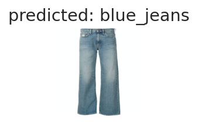

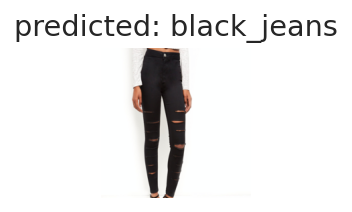

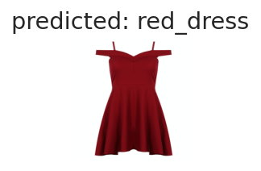

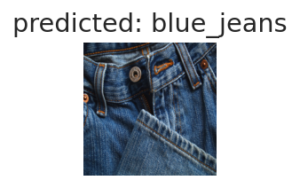

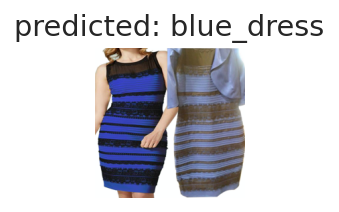

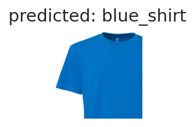

[figure not shown]

[figure not shown]

[figure not shown]

```
[tensor([4, 2, 0, 4, 2, 1, 3, 4, 0, 3, 3, 1, 0, 1, 1, 1, 1, 2, 2, 2, 5, 0, 5, 3,
         3, 2, 4, 5, 5, 5, 1, 3, 4, 1, 5, 3, 2, 0, 3, 3, 2, 3, 1, 3, 0, 1, 3, 0,
         5, 0, 3, 2, 3, 2, 4, 4, 3, 3, 5, 5, 5, 0, 0, 4, 2, 1, 0, 3, 2, 5, 0, 3,
         5, 2, 1, 3, 2, 4, 1, 5, 0, 4, 4, 4, 2, 1, 1, 4, 3, 4, 0, 4, 0, 4, 1, 3,
         5, 0, 5, 4, 0, 3, 4, 3, 3, 0, 2, 1, 5, 3, 1, 1, 2, 0, 3, 3, 4, 0, 4, 3,
         5, 4, 4, 1, 2, 2, 4, 0], device='cuda:0')]
```

```python
visualize_model(model_ft, num_images=10)
```

```python
#losses_df = pd.read_csv(os.path.join(path, 'losses_df.csv'), index_col=0)
losses_df.head(5)
```

|  | epochs | train_losses | val_losses | train_accs | val_accs |
| --- | --- | --- | --- | --- | --- |
| 0 | 1 | 1.621763 | 1.248988 | 0.348677 | 0.597222 |
| 1 | 2 | 0.965403 | 0.649379 | 0.776755 | 0.898148 |
| 2 | 3 | 0.612852 | 0.390530 | 0.850403 | 0.930556 |
| 3 | 4 | 0.443797 | 0.281109 | 0.871116 | 0.972222 |
| 4 | 5 | 0.358988 | 0.217191 | 0.898159 | 0.976852 |

Plot Losses and Accuracies graphs

```python
epochs = losses_df['epochs'].tolist()
epochs[:4]
```

```
[1, 2, 3, 4]
```

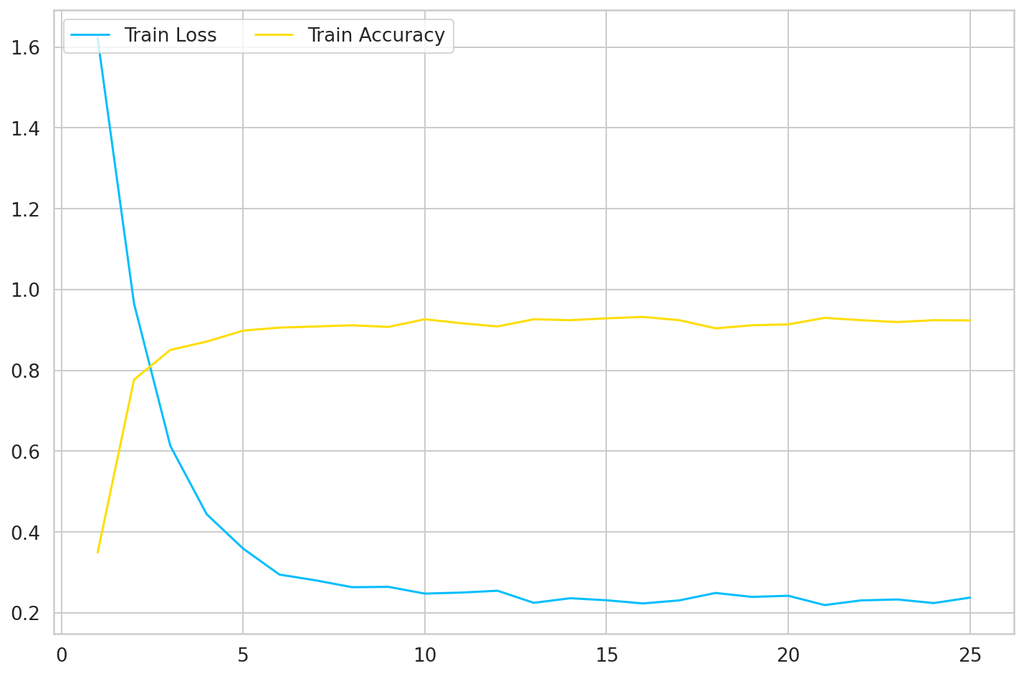

```python
fig = plt.plot(df['epochs'], df['train_losses'])
fig2 = plt.plot(df['epochs'], df['train_accs'])
plt.legend(['Train Loss', 'Train Accuracy'], ncol=2, loc='upper left');
plt.savefig(os.path.join(path, 'Train_Loss_Accuracy_Graph.png'))
```

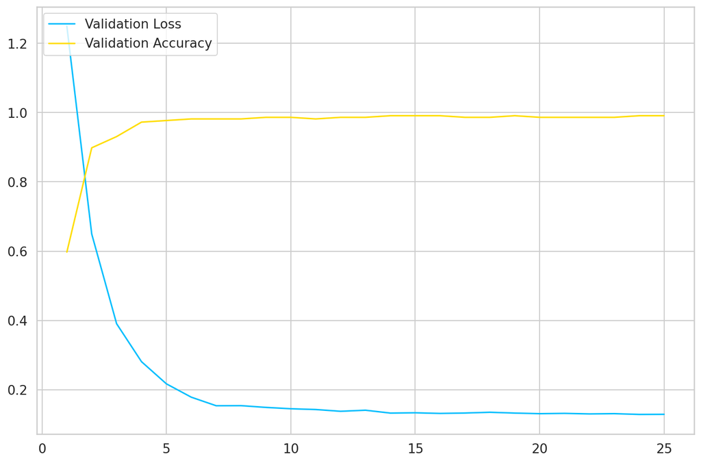

```python
fig = plt.plot(df['epochs'], df['val_losses'])
fig2 = plt.plot(df['epochs'], df['val_accs'])
plt.legend(['Validation Loss', 'Validation Accuracy'], ncol=1, loc='upper left');
plt.savefig(os.path.join(path, 'Validation_Loss_Accuracy_Graph.png'))
```

Train and loss graphs are good. Great!

```python
data_transforms = {
        'test': transforms.Compose([
            transforms.Resize(size=(224, 224), interpolation=3),
            transforms.ToTensor(),
            transforms.Normalize([0.485, 0.456, 0.406], [0.229, 0.224, 0.225])
        ]),
    }
```

```python
test_path = os.path.join(data_dir, 'test')
files_count = len(os.listdir(test_path))
```

```python
image_datasets = {x: datasets.ImageFolder(os.path.join(data_dir, x), data_transforms[x]) for x in ['test']}
dataloaders = {x: torch.utils.data.DataLoader(image_datasets[x], batch_size=files_count, shuffle=True, num_workers=0) for x in ['test']}
class_names = image_datasets['test'].classes
print(f'class_names = {class_names}')
nb_classes = len(class_names)

inputs, classes = next(iter(dataloaders['test']))
```

```
class_names = ['black_jeans', 'blue_dress', 'blue_jeans', 'blue_shirt', 'red_dress', 'red_shirt']
```

```python
from PIL import Image
from sklearn import metrics
from sklearn.metrics import classification_report, accuracy_score
import torchvision
from torchvision import datasets, models, transforms
import torch.nn as nn
import torch.optim as optim
from torch.optim import lr_scheduler
from torch.autograd import Variable

test_transforms = data_transforms['test'] # transforms.Compose([transforms.Resize(224), transforms.ToTensor(),])
```

```python
def predict_image(model, image):
    image_tensor = test_transforms(image).float()
    image_tensor = image_tensor.unsqueeze_(0)
    input = Variable(image_tensor)
    input = input.to(device)
    output = model(input)
    index = output.data.cpu().numpy().argmax()
    return index

y_true, y_pred = [], []
for folder in os.listdir(test_path):
    folder_path = os.path.join(test_path, folder)
    for image_name in os.listdir(folder_path):
        image_path = os.path.join(folder_path, image_name)
        img = Image.open(image_path)
        try:
            y_pred.append(predict_image(model_ft, img))
            y_true.append(folder)
        except RuntimeError:
            pass

print(f'y_true[:10] = {y_true[:10]}')
print(f'y_pred[:10] = {y_pred[:10]}')
class_names_to_id = dict(list([(class_names[i], i) for i in range(len(class_names))]))
print(f'class_names_to_id = {class_names_to_id}')
y_true = [class_names_to_id[item] for item in y_true] # y_pred = [id_to_class[i][1] for i in y_pred]
y_true = torch.as_tensor(np.array(y_true), dtype=int)
y_pred = torch.as_tensor(np.array(y_pred), dtype=int)
```

```
y_true[:10] = ['blue_jeans', 'blue_jeans', 'blue_jeans', 'blue_jeans', 'blue_jeans', 'blue_jeans', 'blue_jeans', 'blue_jeans', 'blue_jeans', 'blue_jeans']
y_pred[:10] = [2, 2, 2, 2, 2, 0, 2, 2, 2, 2]
class_names_to_id = {'black_jeans': 0, 'blue_dress': 1, 'blue_jeans': 2, 'blue_shirt': 3, 'red_dress': 4, 'red_shirt': 5}
```

```python
from sklearn.metrics import classification_report

print(classification_report(y_true, y_pred))
```

```
              precision    recall  f1-score   support

           0       0.94      0.97      0.96        33
           1       0.97      1.00      0.99        38
           2       0.97      0.91      0.94        34
           3       1.00      1.00      1.00        34
           4       1.00      0.97      0.99        37
           5       0.97      1.00      0.98        29

    accuracy                           0.98       205
   macro avg       0.98      0.98      0.98       205
weighted avg       0.98      0.98      0.98       205
```

Classification report looks just fine! Let's see the confusion matrix

```python
confusion_matrix = torch.zeros(nb_classes, nb_classes)
with torch.no_grad():
    for i, (inputs, classes) in enumerate(dataloaders['test']):
        inputs = inputs.to(device)
        classes = classes.to(device)
        outputs = model_ft(inputs)
        _, preds = torch.max(outputs, 1)
        for t, p in zip(classes.view(-1), preds.view(-1)):
            confusion_matrix[t.long(), p.long()] += 1

print(confusion_matrix)
print(confusion_matrix.diag()/confusion_matrix.sum(1))
```

```
tensor([[32.,  0.,  1.,  0.,  0.,  0.],
        [ 0., 38.,  0.,  0.,  0.,  0.],
        [ 2.,  1., 32.,  0.,  0.,  0.],
        [ 0.,  0.,  0., 36.,  0.,  0.],
        [ 0.,  0.,  0.,  0., 36.,  1.],
        [ 0.,  0.,  0.,  0.,  0., 32.]])
tensor([0.9697, 1.0000, 0.9143, 1.0000, 0.9730, 1.0000])
```

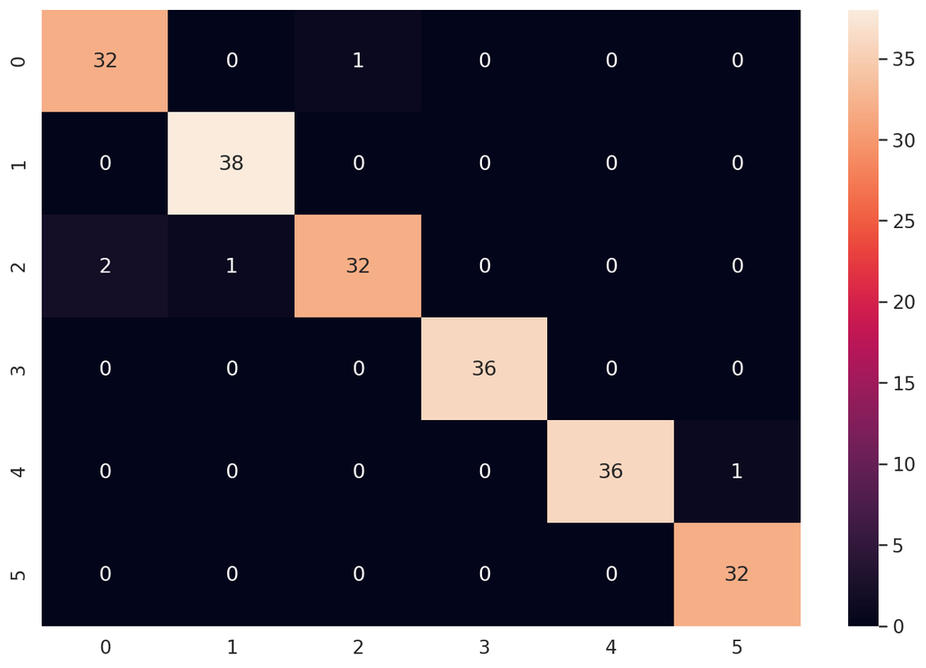

```python
import seaborn as sn
import pandas as pd
import matplotlib.pyplot as plt

sn.heatmap(confusion_matrix, annot=True);
```

It's very clear confusion matrix

Conclusion

My basic points:

1) Use Augmentation is needed when we have small dataset

2) Using a bigger models is not great when we have little of dataset, neural network will start to retraining

3) Quantity of epochs is not like "the more - the better" when we have pre-trained model. Increasing helps but after a few it does not appear to add any benefit.

4) Learning rate - the lower is better, but not always - we have to select the best through experiments

6) Plot and visualize the results after training. Visualization helps many of us see and understand the changes above. I have got an accuracy 98%, good confusion matrix and F1-Score. So, we can say that we created a good model.

Great thanx to PyTorch: Zero to GANs project for participation.